# trisect.Rd

### Set up

```r
library('gbm')
library('ROCR')
library("kohonen")
library('gplots')
library('RColorBrewer')
library("biomaRt")
library("ChIPpeakAnno")
library("org.Hs.eg.db")
```

### Loading source files and data

In this vignette, we provide an example dataset for ZNF143 transcription factor in the form of a `list`, which stores data `list` of four cell types: `Gm12878`, `H1hesc`, `Helas3`, and `K562`. For each cell type, the `list` includes four objects: `trainseq`, `testseq`, `training`, and `testing`. The `training` and `testing` matrix each stores sequences in the rows and features in the columns, with an additional column of sequence labels.

Load EMT functions.

```r
source('R/emt.r')
source('R/clustering.r')
source('R/coherence.r')
```

Load ZNF143 data.

```r
tf <- 'ZNF143'
data("ZNF143")
cells <- names(datalist)
print(cells)
```

```
## [1] "Gm12878" "H1hesc"  "Helas3"  "K562"
```

The `trainseq` columns are :

1. `sequence`: 100 base pair sequence.
2. `seqnames`: Name of the chromosome
3. `start`: The starting position of the binding site in the chromosome
4. `end`: The ending position of the binding site in the chromosome
5. `score`: Signal value
6. `value`: The overall measurement of the enrichment in the region; for non-binding sites it is the value of associated binding site.
7. `peakid`: Id.
8. `label`: Indicator of binding or non-binding.

```r
head(datalist$Gm12878$trainseq)
```

```
##                                                                                               sequence
## 1 TGACAGCCTCAGCCAACCCCACAGGGAGCTCTGAAGCTAGAATGGCCCTTCAGAGTTGACCCAAAATAAGCTAAGAAGGCCAGGCCGTTACACACCTGTT
## 2 TTGCAGCAGGTGCCTGGGAAGCCAGCTTAACATAAGCTGGCTTTGGGCTGTCCTGGCCCAGGCCTGGCCCTGCAGGGTGACTGGACCCTGCCCAGACTTG
## 3 CGCGACCAATGGGCCCCCGCCGCCGGGAAGCCGCGCCCGCCCCCTGGCGGTGGAGGACCAAGCGGGCGCCCGGGCCGGCCAGAGGGAAGGGCCGGAGAGC
## 4 GGCCCCTGTCGGCCGCCAAGCCCCTCCGCCCCTCACAGCGCCCAGGTCCGCGGCCGGGCCTTGATTTTTTGGCGGGGACCGTCATGGCGTCGCAGCCAAA
## 5 GAAACTCAGATCTTTTTGAAGAGGATGCAGCTGTCACAGAAACATGCAGCTGCTGCTGGCAGAGTGCATGGGTCAGAGTGGGCCACCAGGAGCTGTCTGC
## 6 ACCACACAGACCTCCCCCTCCCCACCCCCAGCCCCGCCTGCCCTAGCCCCGCCGCCGCCGCCGCCGAAACTCTTGGGCCTCTGGCCGCCCAGACCCCTCA
##   seqnames     start       end score     value peakid label
## 1     chr1  36192886  36192985   623  97.53589   4476     0
## 2     chr1  26872569  26872668  1000 158.16834   2305     0
## 3     chr7 121036413 121036512   833 130.41128   2805     1
## 4    chr10  94353050  94353149  1000 437.76702    406     0
## 5     chr6   2932247   2932346   673 105.41407   3818     0
## 6    chr12  46123024  46123123   831 130.07808   2815     0
```

The `train` columns are

1. `label`: Indicator of binding or non-binding.
2. `M00001`: TRANSFAC id (i.e. feature 1)
3. `M00002`: TRANSFAC id (i.e. feature 2)
4. `M00003`: TRANSFAC id (i.e. feature 3)
5. `M00004`: TRANSFAC id (i.e. feature 4)

```r
datalist$Gm12878$train[1:5, 1:5]
```

```
##   label   M00001   M00002   M00003   M00004
## 1     0 0.000000 0.000000 2.327241 2.188066
## 2     0 2.402537 2.236245 0.000000 0.000000
## 3     1 0.000000 0.000000 0.000000 2.116407
## 4     0 0.000000 0.000000 0.000000 0.000000
## 5     0 3.376568 2.854730 0.000000 0.000000
```

### Building model for each cell

Note that this steps takes considerable amount of time unless multiple cores are used.

```r
models <- lapply(datalist, function(x) build_emt(x))
names(models) <- cells
```

For the purpose of this vignette, we pre-computed the model and stored the results in an R object which can be easily loaded as follows.

```r
data("models")
sapply(cells, function(x) models[[x]]$auc)
```

```
## Gm12878  H1hesc  Helas3    K562
##   0.896   0.891   0.847   0.902
```

The number of sub-models for each of the four cell-type:

```r
sapply(cells, function(x) models[[x]]$model$n.tree)
```

```
## Gm12878  H1hesc  Helas3    K562
##      25      23      29      32
```

Let’s create an object that stores the sub-model results only.

```r
submodels <- lapply(models, function(x) x$model)
```

### Clustering the submodels across cells

Summarize the cluster membership matrix and plot the constituent cell-specific sub-model counts. In the figure, each row denotes a cluster number and each column denotes a cell line. Each value of the matrix gives the number of sub-models coming from a cell line and belonging to a cluster.

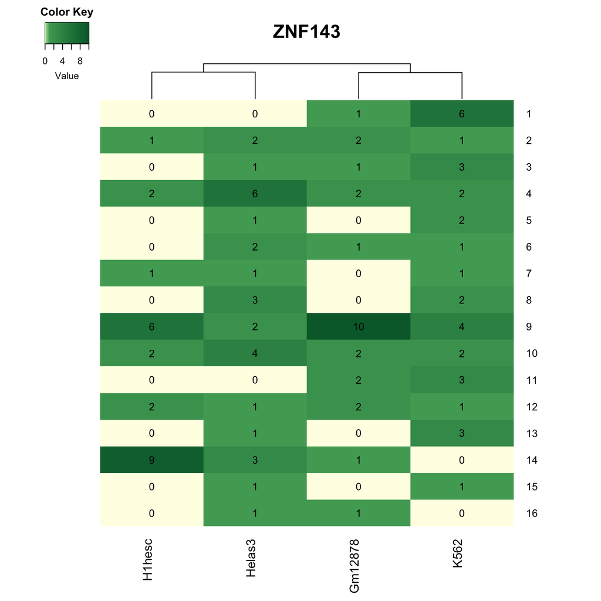

```r
ld <- get_cluster_membership(submodels, clen = 16)
fit <- ld$fit
cluster.membership <- ld$cluster.membership
plot_cluster_membership(cluster.membership, tf)
```

Make a new ensemble object for each cluster.

```r
newEnsembles <- make_cluster_ensembles(submodels, fit, clen = 16)
head(sapply(newEnsembles, class))
```

```
## [1] "gbm" "gbm" "gbm" "gbm" "gbm" "gbm"
```

### Functional assesment of the target genes

Get the target genes (i.e. determined by the nearest gene from a binding site which belong to the cluster) of each cell type from each cluster.

```r
targets <- get_targets(datalist, newEnsembles, clen = 16)
```

How many clusters have expression coherence?

```r
data("expression")
coherence <- setup_exp_coherence(targets, exprsn, exptheK = 1, verbose = F)
df <- exp_coherence(coherence)
sum(df$odds > 1 & df$p.value < 0.05, na.rm = T)
```

```
## [1] 5
```

```r
head(df) #clusters with single-celll and/or insufficient data have NA in the corresponding row
```

```
##    odds      p.value
## 1    NA           NA
## 2 0.615 8.126557e-20
## 3    NA           NA
## 4    NA           NA
## 5 0.911 1.911765e-01
## 6 2.206 9.288746e-85
```

How many clusters have pathway coherence?

```r
data("keggmat")
coherence2 <- setup_pathway_coherence(targets$entrezmat, pathwaymat, verbose=F)
df <- pathway_coherence(coherence2)
sum(df$odds > 1 & df$p.value < 0.05, na.rm = T)
```

```
## [1] 1
```

```r
head(df) #clusters with single-celll and/or insufficient data have NA in the corresponding row
```

```
##    odds      p.value
## 1    NA           NA
## 2 5.012 7.866594e-07
## 3    NA           NA
## 4    NA           NA
## 5 1.194 6.862095e-01
## 6 1.450 2.455643e-01
```